# Simple Linear Regression Notes

Last Updated: September 23, 2024 08:59:17

## Day 1: Intro to Simple Linear Regression

### View the dataset

```r
porsche
```

```
##    Price Age Mileage
## 1   69.4   3   21.50
## 2   56.9   3   43.00
## 3   49.9   2   19.90
## 4   47.4   4   36.00
## 5   42.9   4   44.00
## 6   36.9   6   49.80
## 7   83.0   0    1.30
## 8   72.9   0    0.67
## 9   69.9   2   13.40
## 10  67.9   0    9.70
## 11  66.5   2   15.30
## 12  64.9   2    9.50
## 13  58.9   4   19.10
## 14  57.9   3   12.90
```

[output cut: 16 more lines]

### View the dimensions (rows x columns)

```r
dim(porsche)
```

```
## [1] 30  3
```

### Check the column names

```r
colnames(porsche)
```

```
## [1] "Price"   "Age"     "Mileage"
```

### Look at the first few records

```r
head(porsche, n = 3)
```

```
##   Price Age Mileage
## 1  69.4   3    21.5
## 2  56.9   3    43.0
## 3  49.9   2    19.9
```

### Attach the file so that we can more easily refer to variable names

```r
attach(porsche)
```

### Look at a plot of mileage and price

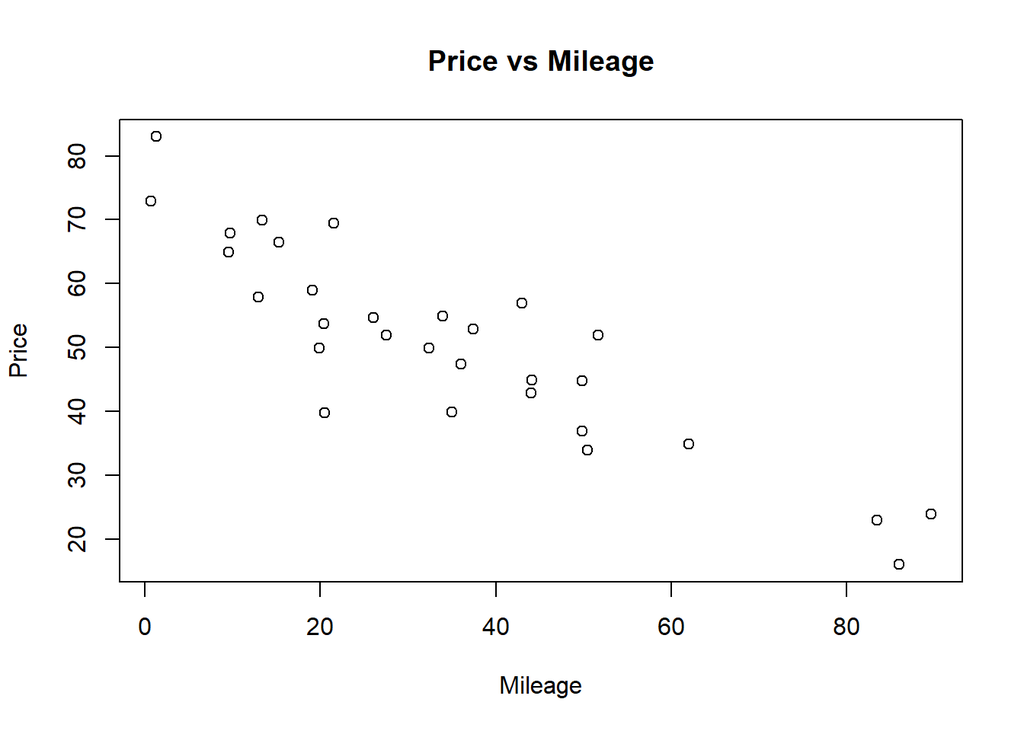

```r
plot(Mileage, Price, main = "Price vs Mileage", xlab = "Mileage", ylab = "Price")
```

The data appear to be distributed in a roughly linear configuration with a negative trend

Use R’s lm function to see the linear model (the defined equation for y-hat)

Store the linear model as porsche_lm

```r
porsche_lm <- lm(Price ~ Mileage)
```

The lm function returns a list with a lot of useful information

```r
length(porsche_lm)
```

```
## [1] 12
```

```r
names(porsche_lm)
```

```
##  [1] "coefficients"  "residuals"     "effects"       "rank"
##  [5] "fitted.values" "assign"        "qr"            "df.residual"
##  [9] "xlevels"       "call"          "terms"         "model"
```

### View the linear model

```r
porsche_lm
```

```
##
## Call:
## lm(formula = Price ~ Mileage)
##
## Coefficients:
## (Intercept)      Mileage
##     71.0905      -0.5894
```

### Other ways to see information

```r
porsche_lm$coefficients
```

```
## (Intercept)     Mileage
##  71.0904527  -0.5894009
```

```r
porsche_lm$coef
```

```
## (Intercept)     Mileage
##  71.0904527  -0.5894009
```

This tells us that the line of best fit for our sample data is pricehat=71.0905 - .5894(Mileage)

### View the regression line

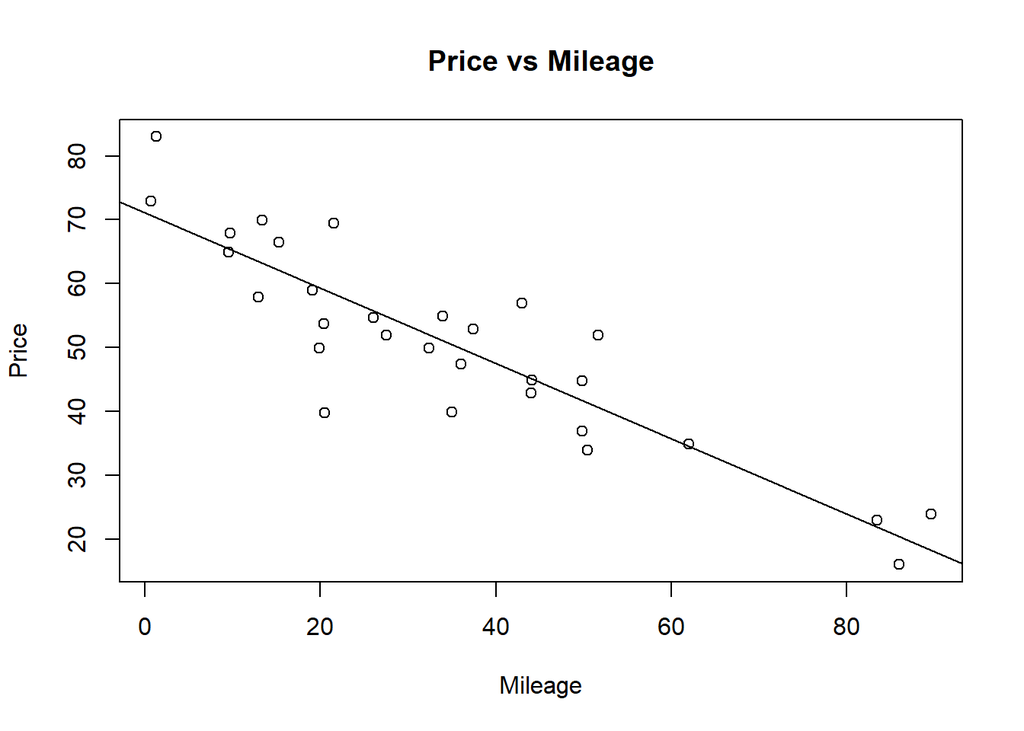

```r
plot(Mileage, Price, main = "Price vs Mileage", xlab = "Mileage", ylab = "Price")
abline(porsche_lm, )
```

#### You can also write abline by giving any intercept and slope such as

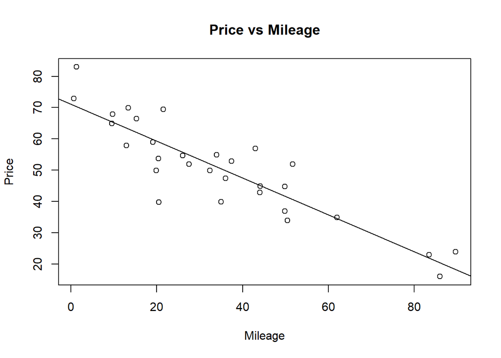

```r
plot(Mileage, Price, main = "Price vs Mileage", xlab = "Mileage", ylab = "Price")
abline(71.0905, -.5894)
```

### Add a horizontal, dotted line at the mean price level

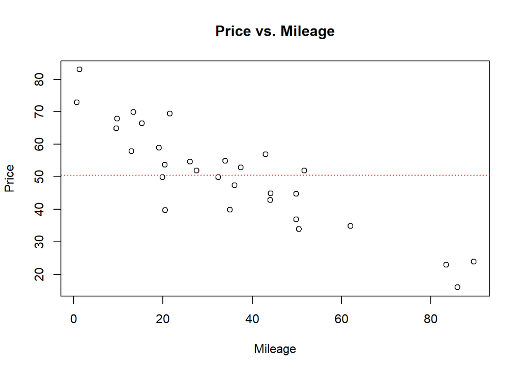

```r
plot(Mileage, Price, main = "Price vs. Mileage", xlab = "Mileage", ylab = "Price")
abline(h = mean(Price), lty = 3, col = "red")
```

#### lty gives characteristics of the line (line type)

- lty1 = solid
- lty2 = dashed
- lty3 = dotted
- lty4 = dot-dash
- lty5 = long dash

### Look at the fitted values and residuals

```r
porsche_lm$residuals
```

```
##           1           2           3           4           5           6
##  10.9816675  11.1537877  -9.4613740  -2.4720189  -2.2568113  -4.8382859
##           7           8           9          10          11          12
##  12.6757685   2.2044459   6.7075199   2.5267364   4.4273817  -0.5911438
##          13          14          15          16          17          18
##  -0.9328948  -5.5871806   3.7902392  -1.0660283  -5.3666735  -2.9819269
##          19          20          21          22          23          24
##  11.2815759  -2.0938623  -0.1978713   3.0617141 -10.5614198 -19.3077334
##          25          26          27          28          29          30
##   0.3524056  -7.4846453   5.6198715   0.9655857  -4.4019719   3.8531424
```

```r
cbind(Mileage, Price, porsche_lm$fitted.values, porsche_lm$residuals)
```

```
##    Mileage Price
## 1    21.50  69.4 58.41833  10.9816675
## 2    43.00  56.9 45.74621  11.1537877
## 3    19.90  49.9 59.36137  -9.4613740
## 4    36.00  47.4 49.87202  -2.4720189
## 5    44.00  42.9 45.15681  -2.2568113
## 6    49.80  36.9 41.73829  -4.8382859
## 7     1.30  83.0 70.32423  12.6757685
## 8     0.67  72.9 70.69555   2.2044459
## 9    13.40  69.9 63.19248   6.7075199
## 10    9.70  67.9 65.37326   2.5267364
## 11   15.30  66.5 62.07262   4.4273817
## 12    9.50  64.9 65.49114  -0.5911438
## 13   19.10  58.9 59.83289  -0.9328948
## 14   12.90  57.9 63.48718  -5.5871806
```

[output cut: 16 more lines]

### Do the same thing, but only look at the first 5 rows

```r
cbind(Mileage, Price, porsche_lm$fitted.values, porsche_lm$residuals)[1:5, ]
```

```
##   Mileage Price
## 1    21.5  69.4 58.41833 10.981667
## 2    43.0  56.9 45.74621 11.153788
## 3    19.9  49.9 59.36137 -9.461374
## 4    36.0  47.4 49.87202 -2.472019
## 5    44.0  42.9 45.15681 -2.256811
```

### Or use the head function to look at the top of the dataset

```r
head(cbind(Mileage, Price, porsche_lm$fitted.values, porsche_lm$residuals))
```

```
##   Mileage Price
## 1    21.5  69.4 58.41833 10.981667
## 2    43.0  56.9 45.74621 11.153788
## 3    19.9  49.9 59.36137 -9.461374
## 4    36.0  47.4 49.87202 -2.472019
## 5    44.0  42.9 45.15681 -2.256811
## 6    49.8  36.9 41.73829 -4.838286
```

### Save the table

```r
porscheTable <- data.frame(Mileage, Price, fits = porsche_lm$fitted.values, resids = porsche_lm$residuals)
```

### View column names

```r
colnames(porscheTable)
```

```
## [1] "Mileage" "Price"   "fits"    "resids"
```

### Change the names of columns 3 and 4

```r
names(porscheTable)[c(3, 4)] = c("fits", "resids")
```

### Check your work

```r
str(porscheTable)
```

```
## 'data.frame':    30 obs. of  4 variables:
##  $ Mileage: num  21.5 43 19.9 36 44 49.8 1.3 0.67 13.4 9.7 ...
##  $ Price  : num  69.4 56.9 49.9 47.4 42.9 36.9 83 72.9 69.9 67.9 ...
##  $ fits   : num  58.4 45.7 59.4 49.9 45.2 ...
##  $ resids : num  10.98 11.15 -9.46 -2.47 -2.26 ...
```

```r
porscheTable
```

```
##    Mileage Price     fits      resids
## 1    21.50  69.4 58.41833  10.9816675
## 2    43.00  56.9 45.74621  11.1537877
## 3    19.90  49.9 59.36137  -9.4613740
## 4    36.00  47.4 49.87202  -2.4720189
## 5    44.00  42.9 45.15681  -2.2568113
## 6    49.80  36.9 41.73829  -4.8382859
## 7     1.30  83.0 70.32423  12.6757685
## 8     0.67  72.9 70.69555   2.2044459
## 9    13.40  69.9 63.19248   6.7075199
## 10    9.70  67.9 65.37326   2.5267364
## 11   15.30  66.5 62.07262   4.4273817
## 12    9.50  64.9 65.49114  -0.5911438
## 13   19.10  58.9 59.83289  -0.9328948
## 14   12.90  57.9 63.48718  -5.5871806
```

[output cut: 16 more lines]

## Day 2: Conditions for Linear Regression

Reopen your R work from yesterday and the Porsche Prices data.

This will take us through 1.2 Conditions for Linear Regression and 1.3 Assessing Conditions

### Summary statistics for porsche_lm

The Residual Standard Error measures the standard deviation of the residuals in the model

```r
summary(porsche_lm)
```

```
##
## Call:
## lm(formula = Price ~ Mileage)
##
## Residuals:
##      Min       1Q   Median       3Q      Max
## -19.3077  -4.0470  -0.3945   3.8374  12.6758
##
## Coefficients:
##             Estimate Std. Error t value Pr(>|t|)
## (Intercept) 71.09045    2.36986    30.0  < 2e-16 ***
## Mileage     -0.58940    0.05665   -10.4 3.98e-11 ***
## ---
## Signif. codes:  0 '***' 0.001 '**' 0.01 '*' 0.05 '.' 0.1 ' ' 1
##
## Residual standard error: 7.17 on 28 degrees of freedom
## Multiple R-squared:  0.7945, Adjusted R-squared:  0.7872
## F-statistic: 108.3 on 1 and 28 DF,  p-value: 3.982e-11
```

### Look at a plot of the residuals

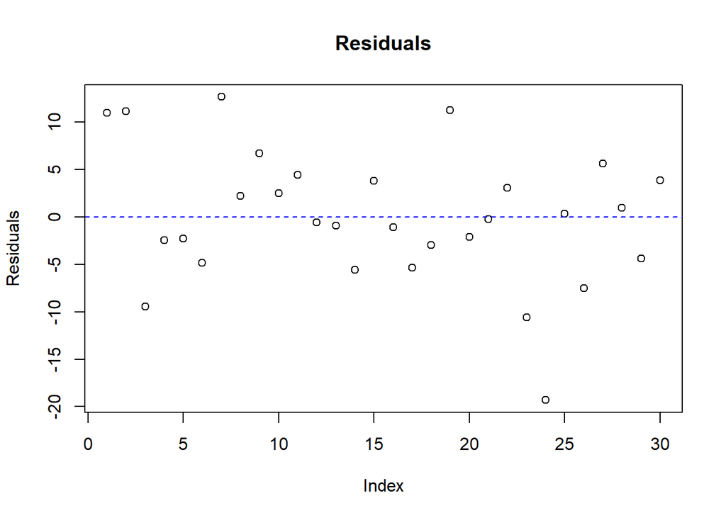

```r
plot(porsche_lm$residuals, main = "Residuals", xlab = "Index", ylab = "Residuals")
abline(h = 0, lty = 2, col = "blue")
```

### Look at the distribution of residuals

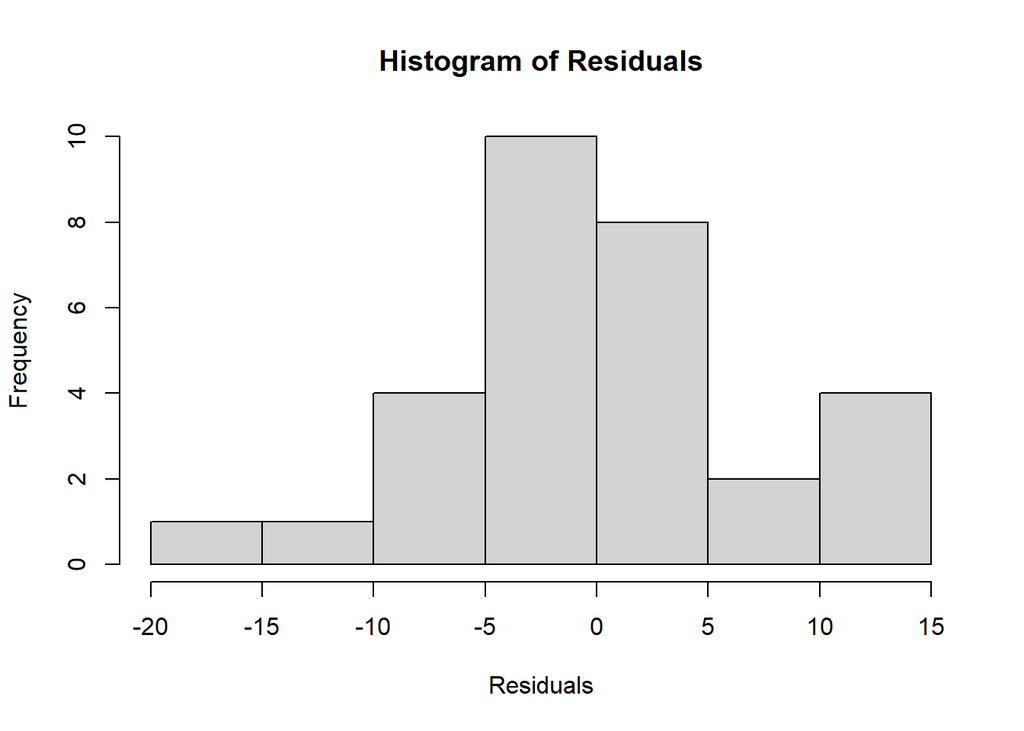

```r
hist(porsche_lm$residuals, main = "Histogram of Residuals", xlab = "Residuals", ylab = "Frequency")
```

The histogram appears to be **unimodal, roughly symmetric**

if our residuals are (nearly) normally distributed, we have some degree of **confidence** in our model

### Plot our distribution of residuals against a normal distribution

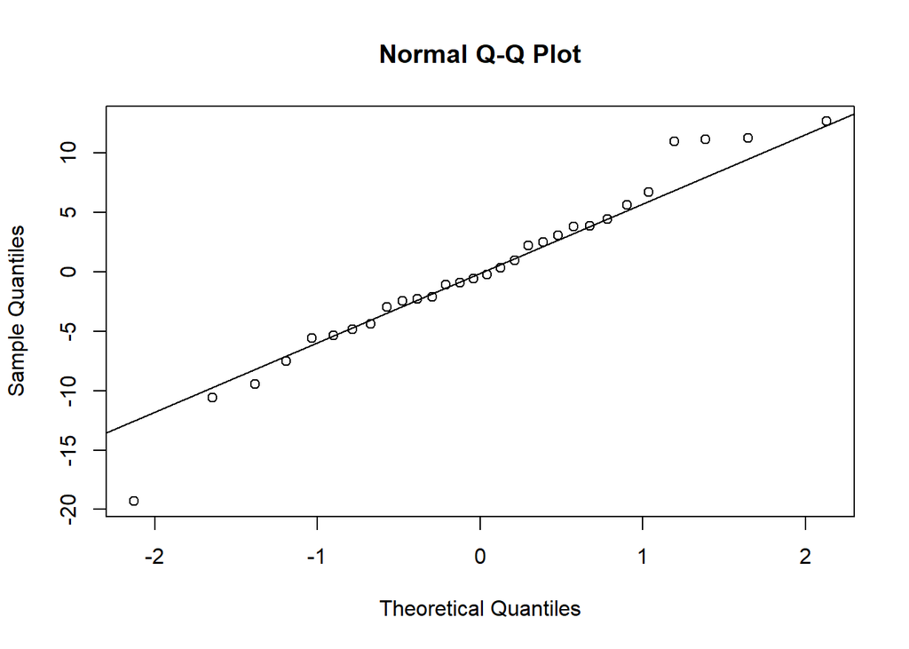

```r
qqnorm(porsche_lm$residuals)
qqline(porsche_lm$residuals)
```

We should see a somewhat linear distribution with no pronounced pattern

Here’s a more advanced way to create a function which will return the qqnorm and qqline you just did

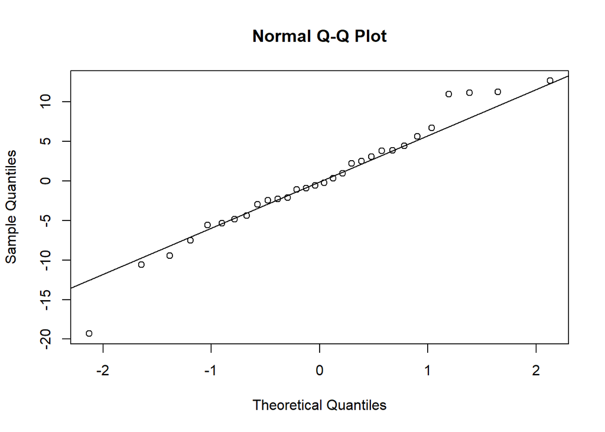

```r
qqnormFunction <- function(x) {
  qqnorm(x)
  qqline(x)
}
qqnormFunction(porsche_lm$residuals)
```